# State of the Neotoma Paleoecology Database

Simon Goring

goring@wisc.edu

true

2025-05-15

# 1 Data Summary

## 1.1 Overall Database Summary

This report details changes to the [Neotoma Paleoecology database](https://neotomadb.org) since **2024-05-15**, and is current up to **2025-05-15**. Full documentation of the database can be found in the Neotoma Database Manual. Recent snapshots of the database can be obtained from the [Neotoma Snapshot website](https://neotomadb.org/snapshots). This report is generated automatically from an [RMarkdown document hosted on GitHub](https://github.com/NeotomaDB/NeotomaStats).

Neotoma contains data from 53,715 datasets and 26,042 unique sites. This represents a considerable contribution from members of the scientific community, including 4,358 primary investigators, 1,348 analysts, and stewards for all 41 constituent databases. There are also invaluable and incalculable contributions from the members of the Neotoma Paleoecology Database Community.

|  | Entries |
| --- | --- |
| Datasets | 4,340 |
| Sites | 3,715 |
| Publications | 610 |
| Authors | 1,128 |
| Countries | 67 |
| Observations | 570,300 |

### 1.1.1 Recent Data Updates

#### 1.1.1.1 Site Additions

[interactive chart not shown]

**Figure 1.** *Locations of newly added sites in Neotoma during the past year. The map is interactive and supports zoom/pan operations. Individual sites can be selected and you will be directed to a link for the [Neotoma Explorer](https://apps.neotomadb.org)*.

Of the 3,749 sites added, 50 have been entered as polygons, while 3,699 are entered as single coordinate points. In general polygons provide more complete information about the site, often representing the particular shape of the depositional environment (lake, archaeological site).

### 1.1.2 Dataset Additions

| databasename | counts |
| --- | --- |
| North American Pollen Database | 1908 |
| East Asian Nonmarine Ostracod Database | 1255 |
| Neotoma | 440 |
| European Pollen Database | 260 |
| Indo-Pacific Pollen Database | 183 |
| Academy of Natural Sciences of Drexel University | 153 |
| Nonmarine Ostracod Distribution in Europe Database | 89 |
| St. Croix Watershed Research Station of the Science Museum of Minnesota | 72 |
| African Pollen Database | 51 |
| Alpine Palynological Database | 34 |

[output cut: 5 more lines]

| datasettype | counts |
| --- | --- |
| Pollen Surface Sample | 2011 |
| Ostracode Surface Sample | 1347 |
| Geochronologic | 350 |
| Pollen | 276 |
| Diatom Surface Sample | 147 |
| Vertebrate Fauna | 140 |
| Lead 210 | 72 |
| Geochemistry | 59 |
| Charcoal | 33 |
| Water Chemistry | 16 |

[output cut: 14 more lines]

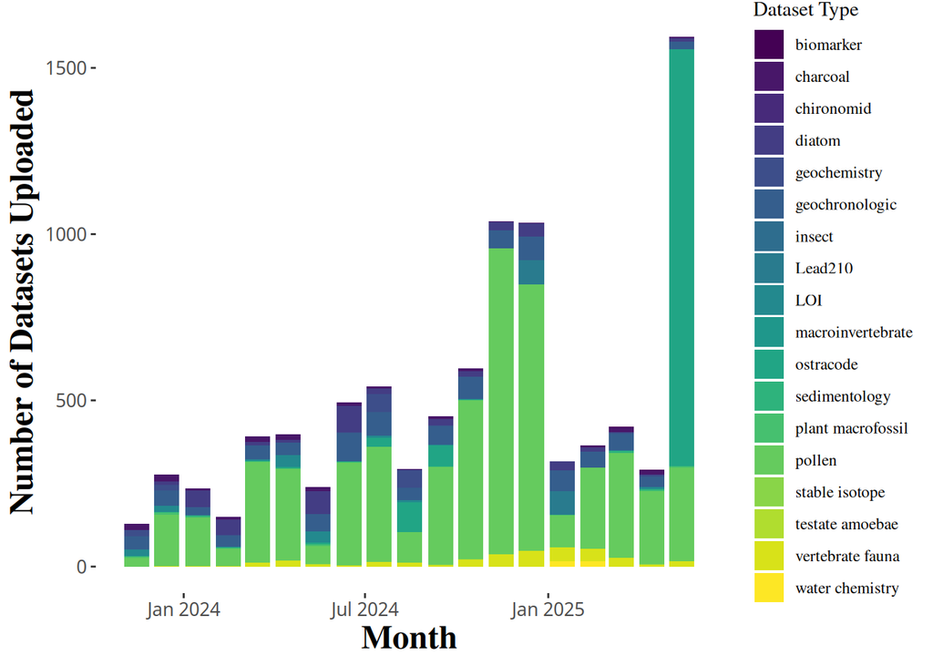

Dataset contributions to Neotoma over the previous 18 months. The large number of Neotoma dataset types makes color coding difficult, however results are detailed specifically in Table 1.

### 1.1.3 Constituent Databases

Neotoma consists of 41 constituent databases. At any one time some databases may be more active than others.

### 1.1.4 Contributors

| databasename | counts |
| --- | --- |
| Cullen, Nicola S. | 2345 |
| Leydet, Michelle | 202 |
| Herbert, Annika | 183 |
| Charles, Donald F. | 138 |
| Horne, David | 89 |
| Ivory, Sarah | 49 |
| Morales del Molino, César | 45 |
| Benito, Xavier | 26 |
| Domic, Alejandra Iboya | 22 |
| Kuneš, Petr | 16 |

[output cut: 14 more lines]

Neotoma relies on significant the efforts of a volunteer group of data stewards and data contributors. Over the last 12 months 24 stewards have contributed data to Neotoma, across a range of constituent databases.

### 1.1.5 API Calls

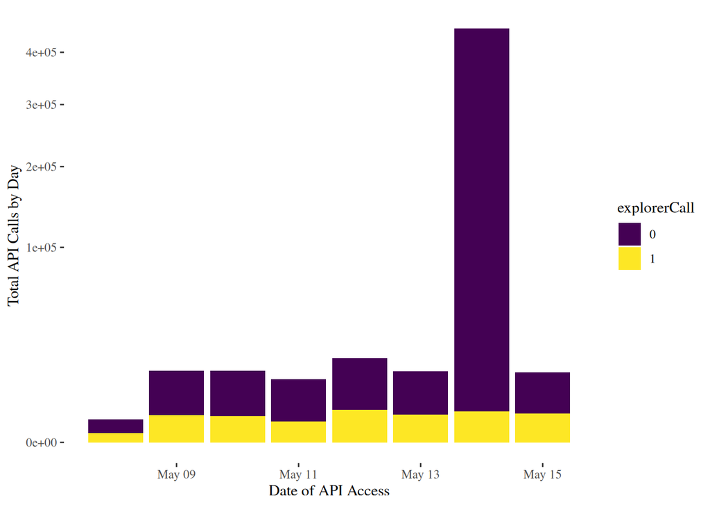

The main APIs delivered a total of 1 GB of data to users since 2025-05-08.

#### 1.1.5.1 Specific API Calls

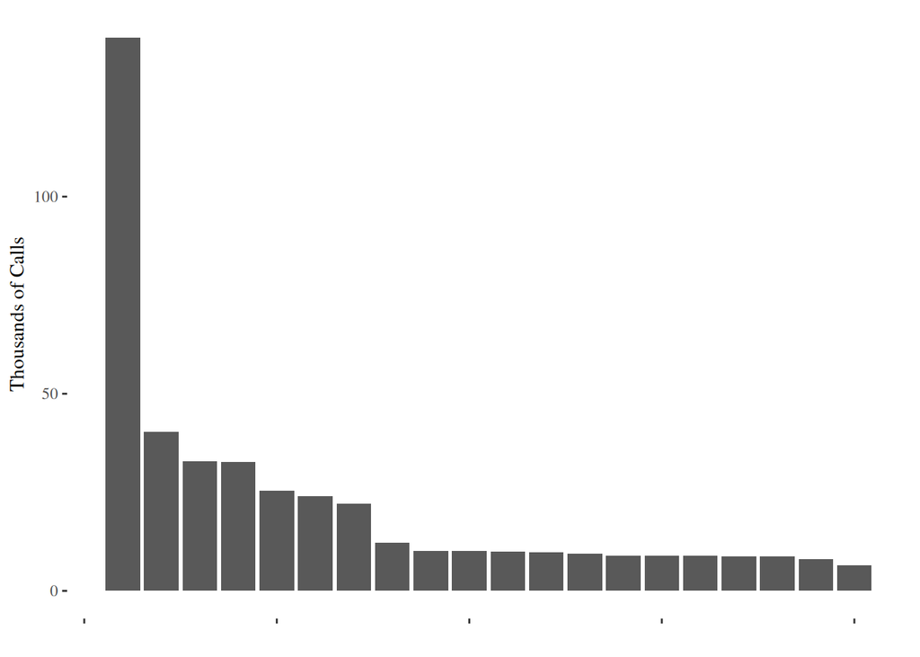

| path | fullcount |
| --- | --- |
| /v1.5/data/datasets | 140317 |
| /v1.5/data/chronologies | 40290 |
| /v1.5/data/publications | 32804 |
| /v2.0/data/datasets | 32682 |
| /v1.5/apps/search | 25477 |
| /v2.0/data/sites | 23944 |
| /v2.0/data/downloads | 22139 |
| /v2.0/apps/constdb/datasets | 12295 |
| /v1.5/data/geopoliticalunits | 10185 |
| /v1.5/dbtables/constituentdatabases | 10052 |

[output cut: 10 more lines]

## 1.2 Data Overview

### 1.2.1 Site Spatial Types

Sites can be added as either points or polygons. Of the 3,749 sites added, 50 of those are entered as site polygons, while 3,699 are entered as single coordinate points. In general polygons provide more complete information about the site, often representing the particular shape of the depositional environment (lake, archaeological site).

### 1.2.2 Site Metadata

|  | Missing |
| --- | --- |
| sitename | 0 |
| altitude | 679 |
| area | 3527 |
| sitedescription | 2636 |
| notes | 2355 |

Among the 3,749 sites added to the Neotoma Paleoecology Database in the past year, not all sites were entered with complete metadata. Complete metadata is critical for better understanding data context, particularly when site notes & descriptions are required to better understand data.

#### 1.2.2.1 Dataset Metadata

|  | Missing |
| --- | --- |
| handle | 0 |
| collunitname | 308 |
| colldate | 2981 |
| colldevice | 4037 |
| waterdepth | 4373 |
| slopeangle | 4543 |
| aspect | 4542 |
| location | 4139 |
| collunitnotes | 1800 |
| datasetname | 2701 |

[output cut: 1 more lines]

### 1.2.3 Taxon Overview

There are 47,682 taxa recorded in the Neotoma Taxonomy table. These are not exclusively taxonomic records, but include other variables, such as laboratory measurements and other detected features within samples.

#### 1.2.3.1 Taxon Hierarchy

Taxonomic records are structured hierarchically, with `highertaxonid` pointing to the next highest `taxonid` in the database. **These hierarchies do not necessarily reflect taxonomic hierarchy**. Issues with taxon hierarchy may be the result of improper identification of high level taxa, failure to identify high level taxa, or duplicate records were multiple higher level taxa are identified.

##### 1.2.3.1.1 Highest-Level Taxa

The highest-level taxa can be identified because they have `taxonid==highertaxonid`. Within the database there are 29 highest level taxa:

| taxonid | taxoncode | taxonname | author | valid | highertaxonid | extinct | taxagroupid | publicationid | validatorid | validatedate | notes | recdatecreated | recdatemodified |
| --- | --- | --- | --- | --- | --- | --- | --- | --- | --- | --- | --- | --- | --- |
| 30 | Bet.pol.diam | Betula mean pollen-grain diameter | Linnaeus | True | 30 | False | BIM |  |  |  |  | 2013-01-01T08:00:00Z | 2013-01-01T08:00:00Z |
| 312 | ind | Indeterminable |  | True | 312 | False | UPA |  | 44 | 2017-09-29 |  | 2013-01-01T08:00:00Z | 2017-09-29T11:16:06Z |
| 313 | unk | Unknown |  | True | 313 | False | UPA |  | 44 | 2017-09-29 |  | 2013-01-01T08:00:00Z | 2017-09-29T11:15:56Z |
| 531 | ca.carb(est) | calcium carbonate (estimated) |  | True | 531 | False | LOI |  | 44 | 2018-05-25 |  | 2013-01-01T08:00:00Z | 2018-05-26T01:08:57Z |
| 532 | org.mat | organic matter |  | True | 532 | False | CAR |  | 44 | 2015-05-23 |  | 2013-01-01T08:00:00Z | 2017-01-07T05:59:39Z |
| 1062 | char | Charcoal |  | True | 1062 | False | CHR |  | 44 | 2020-06-02 |  | 2013-01-01T08:00:00Z | 2020-06-03T06:38:05Z |
| 1414 | unk/ind | Unknown/Indeterminable |  | True | 1414 | False | UPA |  |  |  |  | 2013-01-01T08:00:00Z | 2013-01-01T08:00:00Z |
| 2054 | Algae | Algae |  | True | 2054 | False | ALG |  | 44 | 2017-10-04 | Algae is an informal term for a polyphyletic group including both Eukaryota and Prokaryota. | 2013-01-01T08:00:00Z | 2017-10-04T09:10:37Z |
| 2173 | unk/other | Unknown/Other |  | True | 2173 | False | UPA |  | 44 | 2017-09-29 |  | 2013-01-01T08:00:00Z | 2017-09-29T11:16:40Z |
| 2178 | carb.part | Carbonized particle |  | True | 2178 | False | CHR |  | 44 | 2017-11-01 |  | 2013-01-01T08:00:00Z | 2017-11-02T02:33:24Z |

[output cut: 19 more lines]

This table is provided largely for information, to help identify records that are identified as “highest level”, that should be otherwise grouped.

##### 1.2.3.1.2 Taxa with no relationships

There are 38,831 taxa that represent “leaves” in the Neotoma taxon tree. Of these, 10,406 have no recorded observations within the database (the `taxonid` does not appear in the `ndb.variables` table). These are taxa that are not part of a morpohotaxonomic hierarchy (so there are no dependent taxa), and also have no associated sample records:

| taxonid | taxonname | author | highertaxonid | taxagroupid | count |
| --- | --- | --- | --- | --- | --- |
| 183 | Mimosoideae | de Candolle, 1825 |  | VPL | 0 |
| 187 | Bryopsida undiff. | Pax, 1900 | 659 | BRY | 0 |
| 196 | Osmunda undiff. | Linnaeus, 1753 |  | VPL | 0 |
| 227 | Polygonella fimbriata/P. myriophylla | (Elliott) Horton, 1963\|(Small) Horton, 1963 |  | VPL | 0 |
| 229 | Polygonum undiff. | Linnaeus, 1753 |  | VPL | 0 |
| 273 | Salix vestita | Pursh, 1814[1813] | 271 | VPL | 0 |
| 291 | Shrubs undiff. |  |  | VPL | 0 |
| 303 | Trees undiff. |  |  | VPL | 0 |
| 333 | Schrankia | Willdenow, 1806 | 29012 | VPL | 0 |
| 401 | Amaranthus retroflexus-type | Linnaeus, 1753 | 5431 | VPL | 0 |

[output cut: 10396 more lines]

##### 1.2.3.1.3 Taxa with Undefined Higher Taxa

Some taxa do not have defined `highertaxonid` values. Currently there is a count of 2837 taxa without defined higher taxon IDs. It is unclear why these taxa do not have related higher taxonomic elements.

| taxonid | taxonname | author | highertaxonid | taxagroupid | count |
| --- | --- | --- | --- | --- | --- |
| 14914 | Betula alba | Linnaeus, 1753, nomen ambiguum, nomen rejectum |  | VPL | 0 |
| 36402 | Anas crecca carolinensis | Gmelin, 1789 |  | AVE | 0 |
| 41619 | Blechnum tabulare | (Thunberg) Kuhn, 1868 |  | VPL | 0 |
| 2335 | Lilianae (monocolpate) | Takhtajan, 1967 |  | VPL | 0 |
| 15008 | Felis atrox | Leidy, 1853 |  | MAM | 0 |
| 37902 | Lightfootia | L'Héritier, 1788[1789], nomen illegitimum |  | VPL | 0 |
| 40143 | Myrica serrata | Lamarck, 1786 |  | VPL | 0 |
| 28425 | Opuntia erinacea | Engelmann &amp; J.M. Bigelow, 1856 |  | VPL | 0 |
| 25305 | Unknown-BC01-9-2 | Peros et al., 2010 |  | DIA | 0 |
| 35634 | Taxidea marylandica | Gidley &amp; Gazin, 1933 |  | MAM | 0 |

[output cut: 2827 more lines]

#### 1.2.3.2 Duplicated Taxa

Taxa are identified by `taxonname` and `taxagroupid`. There are instances of duplicate `taxonname`, but these should be represented by distinct `taxagroupid` values. There are 78 taxa where the `taxonname` is duplicated (and the taxon is `valid`).

| taxonname | taxagroupid | json_agg |
| --- | --- | --- |
| Acalles | INS | [ { "id": 21920, "code": "Aca", "count": 0 }, { "id": 48906, "code": "Aca.ge", "count": 0 } ] |
| Achnatherum robustum | VPL | [ { "id": 28342, "code": "Ahn.ro", "count": 1 }, { "id": 29282, "code": "Ahn.rb", "count": 0 } ] |
| Acrostichum aureum | VPL | [ { "id": 52228, "code": "Acr.ar", "count": 0 }, { "id": 9579, "code": "Acr.au", "count": 1 } ] |
| Alstonia-type | VPL | [ { "id": 43089, "code": "Asn-t", "count": 0 }, { "id": 41772, "code": "Asn-t", "count": 1 } ] |
| Amara cf. A. patruelis | INS | [ { "id": 23574, "code": "Ama.pa", "count": 0 }, { "id": 23610, "code": "Ama.cf.A.pa", "count": 1 } ] |
| Anthonomus | INS | [ { "id": 48927, "code": "Ant.ge", "count": 0 }, { "id": 48925, "code": "Ant.ge", "count": 0 }, { "id": 21954, "code": "Any", "count": 0 } ] |
| Arecaceae (type 1) | VPL | [ { "id": 47943, "code": "Areeae(t-1", "count": 0 }, { "id": 37543, "code": "Areeae(t-1)", "count": 1 } ] |
| Asterosporium | FUN | [ { "id": 39261, "code": "Ast", "count": 0 }, { "id": 35283, "code": "Astsp", "count": 1 } ] |
| Bartramiaceae | BRY | [ { "id": 27282, "code": "Bareae", "count": 1 }, { "id": 46173, "code": "Bareae", "count": 0 } ] |
| Bistorta macrophylla | VPL | [ { "id": 51302, "code": "Bst.ma", "count": 0 }, { "id": 49535, "code": "Bis.ma", "count": 1 } ] |

[output cut: 68 more lines]

##### 1.2.3.2.1 Duplicated Taxon Codes

It is possible to have duplicate taxon codes in the database provided the taxa are within different taxon group IDs. However, there may be instances where a taxon code is repeated within the same group. The following taxon identifiers are repeated multiple times within an ecological group:

| taxoncode | taxagroupid | json_agg |
| --- | --- | --- |
| Ant.ge | INS | [{"id": 48925, "code": "Anthonomus", "count": 0}, {"id": 48927, "code": "Anthonomus", "count": 0}] |
| Api | VPL | [{"id": 1764, "code": "Apium", "count": 1}, {"id": 49518, "code": "Apioideae", "count": 0}] |
| Arc | VPL | [{"id": 49521, "code": "Arctotidinae", "count": 0}, {"id": 23, "code": "Arceuthobium", "count": 4}] |
| Arcida | MOL | [{"id": 52843, "code": "Arcida", "count": 0}, {"id": 9309, "code": "Arcoida", "count": 0}] |
| Asn-t | VPL | [{"id": 41772, "code": "Alstonia-type", "count": 1}, {"id": 43089, "code": "Alstonia-type", "count": 0}] |
| Atr | VPL | [{"id": 49525, "code": "Atripliceae", "count": 0}, {"id": 49524, "code": "Atractylodes", "count": 0}, {"id": 3785, "code": "Anthericum", "count": 1}] |
| Ave | VPL | [{"id": 49526, "code": "Aveninae", "count": 0}, {"id": 3915, "code": "Avena", "count": 1}] |
| Bac.gl | VPL | [{"id": 3508, "code": "Baccharis glomeruliflora", "count": 1}, {"id": 49527, "code": "Baccharis glutinosa", "count": 0}] |
| Bareae | BRY | [{"id": 27282, "code": "Bartramiaceae", "count": 1}, {"id": 46173, "code": "Bartramiaceae", "count": 0}] |
| Bau | VPL | [{"id": 1968, "code": "Bauhinia", "count": 2}, {"id": 49531, "code": "Bauhiniinae", "count": 0}] |

[output cut: 102 more lines]

#### 1.2.3.3 Taxon Synonymys

Although taxonomies are continually updated, Neotoma provides the ability to have users enter the original taxonomic information, and then reference particular synonomies, associated with particular publications, or attributed to specific Neotoma stewards or contacts. This relies on several interacting tables, in particular `ndb.synonyms`, and `ndb.synonomy`. `ndb.synonyms` indicates the links between taxa (in this case `validtaxonid` and `invalidtaxonid`).

Critically, there is no direct *PK*/*FK* link between these tables. Thus, it is possible for a synonymy at the dataset level to have no attribution for the synonymy. While `ndb.synonyms` also provides the opportunity to define a `synonymtype`, the `synonymy` does not, except by relating the `validtaxonid` and `invalidtaxonid` in `ndb.synonyms` to the `taxonid` and `reftaxonid` of `ndb.synonymy`.

The database currently contains 10,479 datasets with synonymys, and a total of 2,825 attributed synonyms. Of the synonyms with associated datastids, there are 853 synonymys without links in the synonyms table. There are 1 synonyms where there is no attributed contactid or publication.

There are 214 synonymys where multiple different publications are used to attribute the synonymy. There are also 532 where multiple different individuals are identified as assigning the synonym. There are 1,466 synonyms without any associated publication.

#### 1.2.3.4 Duplicated Variables

We use variable IDs (PK: `ndb.variables.variableid`) to link a taxon, the element, context and units. In general, we don’t expect that these should ever be duplicated, since we can use the same variable ID over and over again, for the given combination. Having said that, we do see replication, and it’s not clear why.

| variableid | taxonid | variableelementid | variableunitsid | variablecontextid | recdatecreated | recdatemodified | count |
| --- | --- | --- | --- | --- | --- | --- | --- |

| taxonid | count | taxonname |
| --- | --- | --- |

### 1.2.4 Sites and Datasets

Issues with sites include sites with no associated datasets, duplicated sites and, potentially, sites with missing data.

When we examine sites, we find that there are 902 sites with *exactly* duplicated site geometries. These sites are distributed globally, and distributed across constituent databases.

| json_agg | st_asgeojson |
| --- | --- |
| [{"db": "Tropical South American Diatom Database", "siteid": 31531, "datasets": [59626], "sitename": "Cactus Ridge", "datecreated": "2024-08-18T13:50:41", "datemodified": "2025-05-15T11:24:30"}, {"db"… | ['{\n "type": "Point",\n "coordinates": [\n -91.39,\n -0.234\n ]\n}\n'] |
| [{"db": "Tropical South American Diatom Database", "siteid": 31532, "datasets": [59627], "sitename": "Cementario", "datecreated": "2024-08-18T13:51:04", "datemodified": "2025-05-15T11:24:30"}, {"db": … | ['{\n "type": "Point",\n "coordinates": [\n -91.39,\n -0.229\n ]\n}\n'] |
| [{"db": "Tropical South American Diatom Database", "siteid": 31530, "datasets": [59625], "sitename": "Beagle", "datecreated": "2024-08-18T13:50:18", "datemodified": "2025-05-15T11:24:30"}, {"db": "Tro… | ['{\n "type": "Point",\n "coordinates": [\n -91.351,\n -0.281\n ]\n}\n'] |
| [{"db": "Tropical South American Diatom Database", "siteid": 31534, "datasets": [59630], "sitename": "Fernandina", "datecreated": "2024-08-18T13:52:03", "datemodified": "2025-05-15T11:24:30"}, {"db": … | ['{\n "type": "Point",\n "coordinates": [\n -91.387,\n -0.358\n ]\n}\n'] |
| [{"db": "Tropical South American Diatom Database", "siteid": 31533, "datasets": [59629], "sitename": "El Sarten", "datecreated": "2024-08-18T13:51:39", "datemodified": "2025-05-15T11:24:30"}, {"db": "… | ['{\n "type": "Point",\n "coordinates": [\n -90.813,\n -0.247\n ]\n}\n'] |
| [{"db": "Tropical South American Diatom Database", "siteid": 31529, "datasets": [59624], "sitename": "Bainbridge", "datecreated": "2024-08-18T13:49:51", "datemodified": "2025-05-15T11:24:30"}, {"db": … | ['{\n "type": "Point",\n "coordinates": [\n -90.565,\n -0.352\n ]\n}\n'] |
| [{"db": "Latin American Pollen Database", "siteid": 30200, "datasets": [57207], "sitename": "HuaypoB", "datecreated": "2023-05-30T18:42:02", "datemodified": "2025-05-15T11:24:30"}, {"db": "Latin Ameri… | ['{\n "type": "Point",\n "coordinates": [\n -72.134,\n -13.4\n ]\n}\n'] |
| [{"db": "Latin American Pollen Database", "siteid": 30242, "datasets": [57253], "sitename": "T7t-644.2D2-3cm", "datecreated": "2023-05-31T17:06:30", "datemodified": "2025-05-15T11:24:30"}, {"db": "Lat… | ['{\n "type": "Point",\n "coordinates": [\n -71.626652,\n -13.17484\n ]\n}\n'] |
| [{"db": "Latin American Pollen Database", "siteid": 27211, "datasets": [48612, 48613, 48614], "sitename": "Cerro Toledo", "datecreated": "2020-06-26T18:42:48", "datemodified": "2025-05-15T11:24:30"}, … | ['{\n "type": "Point",\n "coordinates": [\n -79.111527778,\n -4.374611111\n ]\n}\n'] |
| [{"db": "Latin American Pollen Database", "siteid": 23758, "datasets": [41116, 41117, 41118], "sitename": "Cocha Caranga Forest", "datecreated": "2019-01-27T23:01:42", "datemodified": "2025-05-15T11:2… | ['{\n "type": "Point",\n "coordinates": [\n -79.159583333,\n -4.045861111\n ]\n}\n'] |

[output cut: 892 more lines]

#### 1.2.4.1 Sites without CollectionUnits or Datasets

This is likely the result of failed uploads during the Tilia upload process (see [Tilia upload reference here](https://github.com/NeotomaDB/tilia_api/blob/production/tiliauploadref.yaml)). To ensure that these records are properly cleaned we need to validate that there are collection units and datasets associated with the records, and, ultimately, we need to parse the records from Tilia in such a way that we are not committing individual steps within the upload process, but rather, processing the entire file at once.

#### 1.2.4.2 Sites without analysis units

Some sites appear to have been submitted, with collection units but no registered analysis units associated with them:

| siteid | sitename | collectionunits | datasets |
| --- | --- | --- | --- |
| 1004 | 4 [HFL4] | 27038 | {39106} |
| 1004 | 4 [HFL4] | 27074 | {39143} |
| 1005 | 5 [HFL5] | 27044 | {39112} |
| 1005 | 5 [HFL5] | 27080 | {39149} |
| 1006 | 6 [HFL6] | 27052 | {39120} |
| 1006 | 6 [HFL6] | 27088 | {39157} |
| 1007 | 7 [HFL7] | 27059 | {39127} |
| 1007 | 7 [HFL7] | 27095 | {39164} |
| 1008 | 8 [HFL8] | 27060 | {39128} |
| 1008 | 8 [HFL8] | 27096 | {39165} |

[output cut: 164 more lines]

This is also likely the result of failed uploads during the Tilia upload process. To ensure that these records are properly cleaned we need to validate that there are collection units and datasets associated with the records, and, ultimately, we need to parse the records from Tilia in such a way that we are not committing individual steps within the upload process, but rather, processing the entire file at once.

### 1.2.5 Stewards & Tilia Usage

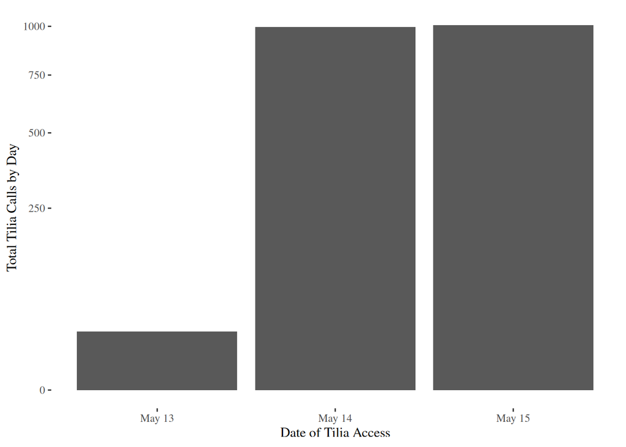

A total of 2,029 calls to the Tilia API were made since 2025-05-13.